# Simple Classification for Glass Type Using R

David Lowe

March 30, 2018

Template Credit: Adapted from a template made available by Dr. Jason Brownlee of Machine Learning Mastery (http://machinelearningmastery.com/)

https://machinelearningmastery.com/standard-machine-learning-datasets/.

Dataset Used: Glass Identification Data Set Data Set ML Model: Classification with real number attributes Dataset Reference: https://archive.ics.uci.edu/ml/datasets/Glass+Identification

For more information on this case study project and performance benchmarks, please consult: https://www.kaggle.com/uciml/glass

The glass identification dataset involves predicting the six types of glass, defined by their oxide content (i.e., Na, Fe, K, .and so forth). The criminological investigation was the motivation for the study of classification of types of glass. At the scene of the crime, the glass left can be used as evidence, if it is correctly identified!

The purpose of this project is to analyze a dataset using various machine learning algorithms and to document the steps using a template. The project aims to touch on the following areas:

Working through machine learning problems from end-to-end requires a structured modeling approach. Working problems through a project template can encourage you to think about the problem more critically, to challenge your assumptions, and to get good at all parts of a modeling project.

Any predictive modeling machine learning project can be broken down into about 6 common tasks:

1. Define Problem
2. Summarize Data
3. Prepare Data
4. Evaluate Algorithms
5. Improve Accuracy or Results
6. Finalize Model and Present Results

We will compare several different algorithms and determine which one would yield the best results.

## 1. Prepare Problem

### 1.a) Load libraries

```r
library(mlbench)
library(caret)
```

```r
library(corrplot)
```

### 1.b) Load dataset

```r
data(Glass)
dataset <- Glass
seedNum <- 888
```

### 1.c) Split-out validation dataset

Normally, we would create a training (variable name “dataset”) and a validation (variable name “validation”) dataset. Because this dataset is relatively small, we will opt to test the algorithms with the full set of data and not splitting.

```r
# Not applicable for this iteration of the project.
```

## 2. Summarize Data

To gain a better understanding of the data that we have on-hand, we will leverage a number of descriptive statistics and data visualization techniques. The plan is to use the results to consider new questions, review assumptions, and validate hypotheses that we can investigate later with specialized models.

### 2.a) Descriptive statistics

#### 2.a.i) Dimensions of the dataset.

```r
dim(dataset)
```

```
## [1] 214  10
```

#### 2.a.ii) Types of the attributes.

```r
sapply(dataset, class)
```

```
##        RI        Na        Mg        Al        Si         K        Ca
## "numeric" "numeric" "numeric" "numeric" "numeric" "numeric" "numeric"
##        Ba        Fe      Type
## "numeric" "numeric"  "factor"
```

#### 2.a.iii) Peek at the data itself.

```r
head(dataset, n=20)
```

```
##         RI    Na   Mg   Al    Si    K   Ca Ba   Fe Type
## 1  1.52101 13.64 4.49 1.10 71.78 0.06 8.75  0 0.00    1
## 2  1.51761 13.89 3.60 1.36 72.73 0.48 7.83  0 0.00    1
## 3  1.51618 13.53 3.55 1.54 72.99 0.39 7.78  0 0.00    1
## 4  1.51766 13.21 3.69 1.29 72.61 0.57 8.22  0 0.00    1
## 5  1.51742 13.27 3.62 1.24 73.08 0.55 8.07  0 0.00    1
## 6  1.51596 12.79 3.61 1.62 72.97 0.64 8.07  0 0.26    1
## 7  1.51743 13.30 3.60 1.14 73.09 0.58 8.17  0 0.00    1
## 8  1.51756 13.15 3.61 1.05 73.24 0.57 8.24  0 0.00    1
## 9  1.51918 14.04 3.58 1.37 72.08 0.56 8.30  0 0.00    1
## 10 1.51755 13.00 3.60 1.36 72.99 0.57 8.40  0 0.11    1
## 11 1.51571 12.72 3.46 1.56 73.20 0.67 8.09  0 0.24    1
## 12 1.51763 12.80 3.66 1.27 73.01 0.60 8.56  0 0.00    1
## 13 1.51589 12.88 3.43 1.40 73.28 0.69 8.05  0 0.24    1
## 14 1.51748 12.86 3.56 1.27 73.21 0.54 8.38  0 0.17    1
## 15 1.51763 12.61 3.59 1.31 73.29 0.58 8.50  0 0.00    1
## 16 1.51761 12.81 3.54 1.23 73.24 0.58 8.39  0 0.00    1
## 17 1.51784 12.68 3.67 1.16 73.11 0.61 8.70  0 0.00    1
## 18 1.52196 14.36 3.85 0.89 71.36 0.15 9.15  0 0.00    1
## 19 1.51911 13.90 3.73 1.18 72.12 0.06 8.89  0 0.00    1
## 20 1.51735 13.02 3.54 1.69 72.73 0.54 8.44  0 0.07    1
```

#### 2.a.iv) Summarize the levels of the class attribute.

```r
x <- dataset[,1:9]
y <- dataset[,10]
cbind(freq=table(y), percentage=prop.table(table(y))*100)
```

```
##   freq percentage
## 1   70  32.710280
## 2   76  35.514019
## 3   17   7.943925
## 5   13   6.074766
## 6    9   4.205607
## 7   29  13.551402
```

#### 2.a.v) Summarize correlations between input variables.

```r
cor(x)
```

```
##               RI          Na           Mg          Al          Si
## RI  1.0000000000 -0.19188538 -0.122274039 -0.40732603 -0.54205220
## Na -0.1918853790  1.00000000 -0.273731961  0.15679367 -0.06980881
## Mg -0.1222740393 -0.27373196  1.000000000 -0.48179851 -0.16592672
## Al -0.4073260341  0.15679367 -0.481798509  1.00000000 -0.00552372
## Si -0.5420521997 -0.06980881 -0.165926723 -0.00552372  1.00000000
## K  -0.2898327111 -0.26608650  0.005395667  0.32595845 -0.19333085
## Ca  0.8104026963 -0.27544249 -0.443750026 -0.25959201 -0.20873215
## Ba -0.0003860189  0.32660288 -0.492262118  0.47940390 -0.10215131
## Fe  0.1430096093 -0.24134641  0.083059529 -0.07440215 -0.09420073
##               K         Ca            Ba           Fe
## RI -0.289832711  0.8104027 -0.0003860189  0.143009609
## Na -0.266086504 -0.2754425  0.3266028795 -0.241346411
## Mg  0.005395667 -0.4437500 -0.4922621178  0.083059529
## Al  0.325958446 -0.2595920  0.4794039017 -0.074402151
## Si -0.193330854 -0.2087322 -0.1021513105 -0.094200731
## K   1.000000000 -0.3178362 -0.0426180594 -0.007719049
## Ca -0.317836155  1.0000000 -0.1128409671  0.124968219
## Ba -0.042618059 -0.1128410  1.0000000000 -0.058691755
## Fe -0.007719049  0.1249682 -0.0586917554  1.000000000
```

#### 2.a.vi) Statistical summary of all attributes.

```r
summary(dataset)
```

```
##        RI              Na              Mg              Al
##  Min.   :1.511   Min.   :10.73   Min.   :0.000   Min.   :0.290
##  1st Qu.:1.517   1st Qu.:12.91   1st Qu.:2.115   1st Qu.:1.190
##  Median :1.518   Median :13.30   Median :3.480   Median :1.360
##  Mean   :1.518   Mean   :13.41   Mean   :2.685   Mean   :1.445
##  3rd Qu.:1.519   3rd Qu.:13.82   3rd Qu.:3.600   3rd Qu.:1.630
##  Max.   :1.534   Max.   :17.38   Max.   :4.490   Max.   :3.500
##        Si              K                Ca               Ba
##  Min.   :69.81   Min.   :0.0000   Min.   : 5.430   Min.   :0.000
##  1st Qu.:72.28   1st Qu.:0.1225   1st Qu.: 8.240   1st Qu.:0.000
##  Median :72.79   Median :0.5550   Median : 8.600   Median :0.000
##  Mean   :72.65   Mean   :0.4971   Mean   : 8.957   Mean   :0.175
##  3rd Qu.:73.09   3rd Qu.:0.6100   3rd Qu.: 9.172   3rd Qu.:0.000
##  Max.   :75.41   Max.   :6.2100   Max.   :16.190   Max.   :3.150
##        Fe          Type
##  Min.   :0.00000   1:70
##  1st Qu.:0.00000   2:76
##  Median :0.00000   3:17
##  Mean   :0.05701   5:13
##  3rd Qu.:0.10000   6: 9
##  Max.   :0.51000   7:29
```

### 2.b) Data visualizations

#### 2.b.i) Univariate plots to better understand each attribute.

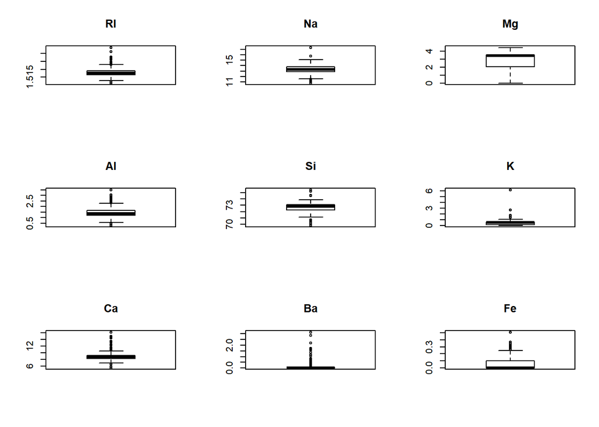

```r
# boxplots for each attribute
par(mfrow=c(3,3))
for(i in 1:9) {
    boxplot(dataset[,i], main=names(dataset)[i])
}
```

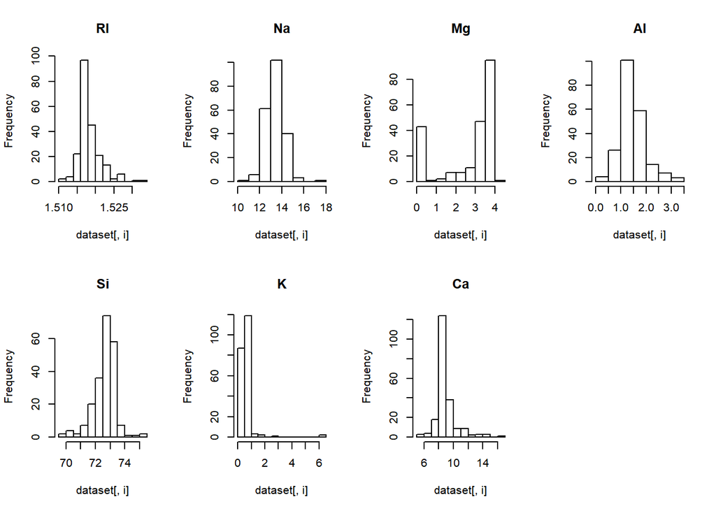

```r
# histograms each attribute
par(mfrow=c(2,4))
for(i in 1:7) {
    hist(dataset[,i], main=names(dataset)[i])
}
```

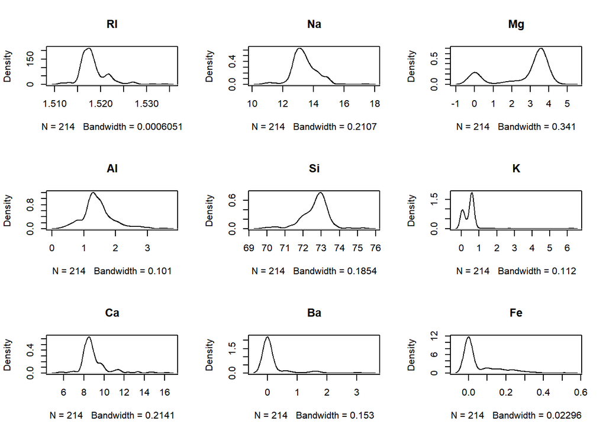

```r
# density plot for each attribute
par(mfrow=c(3,3))
for(i in 1:9) {
    plot(density(dataset[,i]), main=names(dataset)[i])
}
```

#### 2.b.ii) Multivariate plots to better understand the relationships between attributes

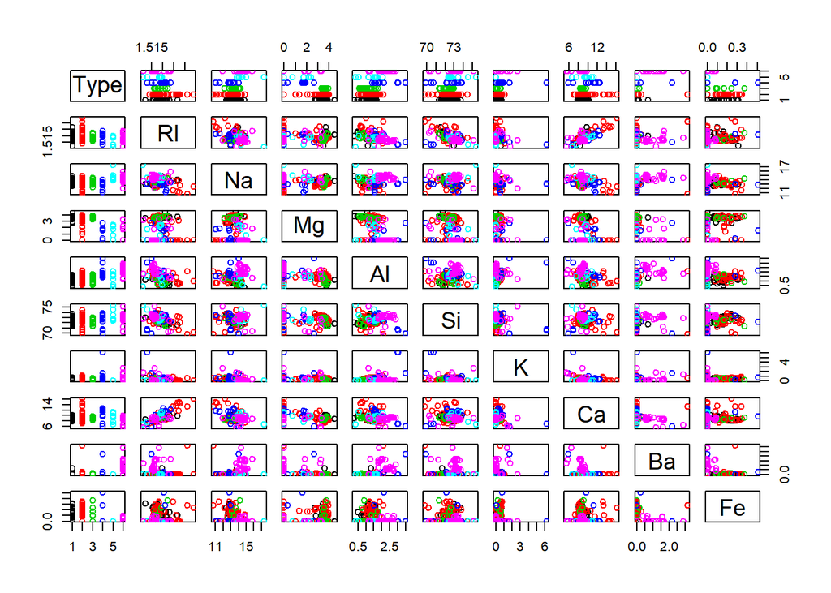

```r
# scatterplot matrix colored by class
pairs(Type~., data=dataset, col=dataset$Type)
```

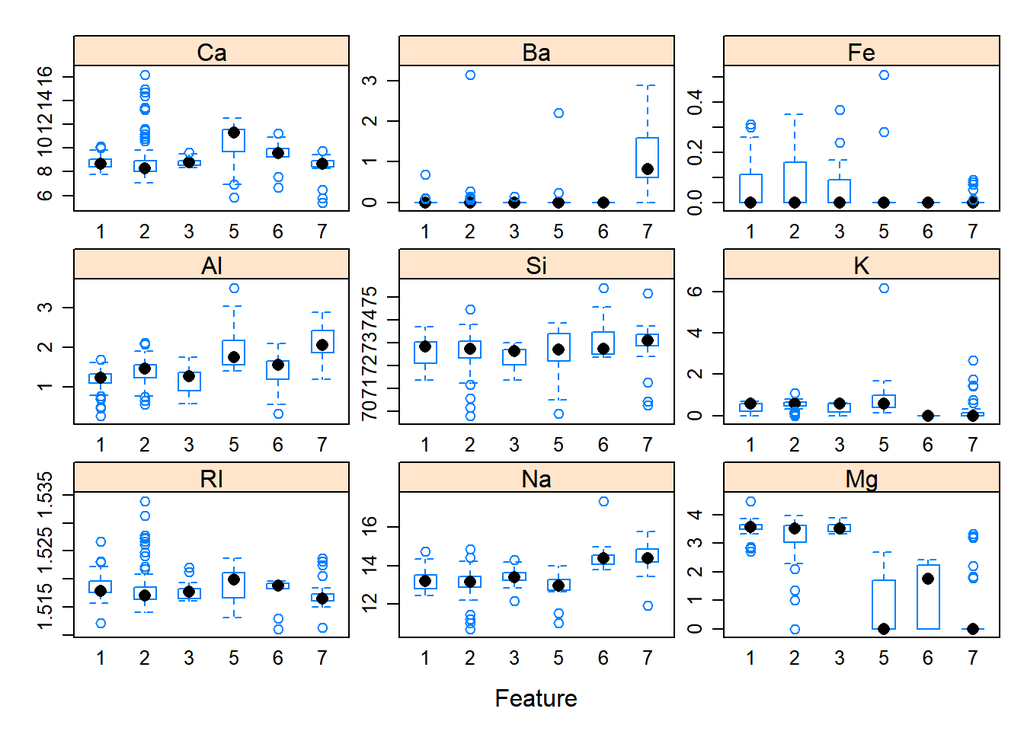

```r
# box and whisker plots for each attribute by class
scales <- list(x=list(relation="free"), y=list(relation="free"))
featurePlot(x=x, y=y, plot="box", scales=scales)
```

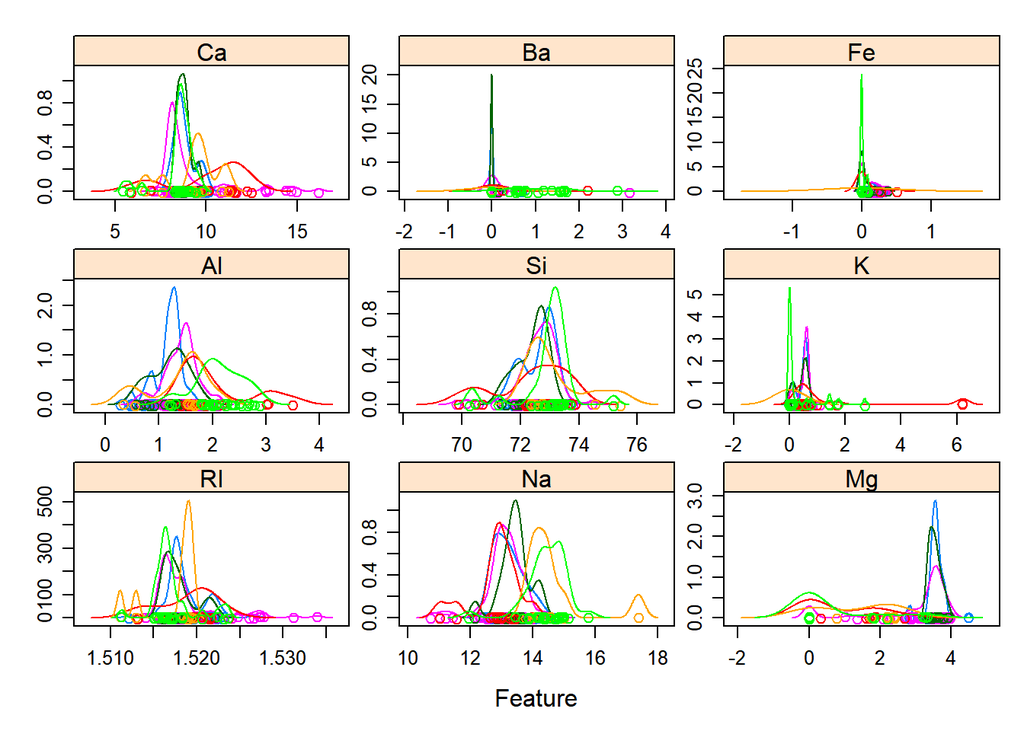

```r
# density plots for each attribute by class value
featurePlot(x=x, y=y, plot="density", scales=scales)
```

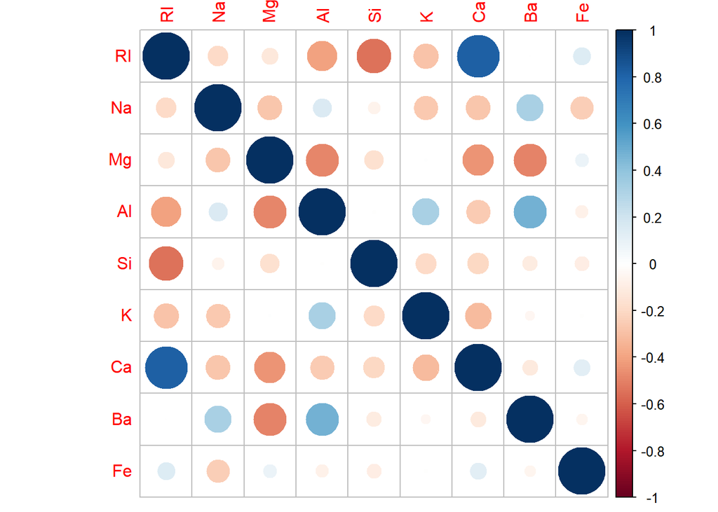

```r
# correlation plot
correlations <- cor(x)
corrplot(correlations, method="circle")
```

## 3. Prepare Data

Some dataset may require additional preparation activities that will best exposes the structure of the problem and the relationships between the input attributes and the output variable. Some data-prep tasks might include:

- Cleaning data by removing duplicates, marking missing values and even imputing missing values.
- Feature selection where redundant features may be removed.
- Data transforms where attributes are scaled or redistributed in order to best expose the structure of the problem later to learning algorithms.

### 3.a) Data Cleaning

```r
# Not applicable for this iteration of the project.
```

### 3.b) Feature Selection

```r
# Not applicable for this iteration of the project.
```

### 3.c) Data Transforms

```r
# Standardizing the attributes to improve accuracy for all algorithms
dataset[,1:9] <- scale(dataset[,1:9])
head(dataset, n=20)
```

```
##            RI         Na        Mg          Al          Si           K
## 1   0.8708258  0.2842867 1.2517037 -0.69082217 -1.12444556 -0.67013422
## 2  -0.2487502  0.5904328 0.6346799 -0.17006149  0.10207972 -0.02615193
## 3  -0.7196308  0.1495824 0.6000157  0.19046513  0.43776033 -0.16414813
## 4  -0.2322859 -0.2422846 0.6970756 -0.31026629 -0.05284979  0.11184428
## 5  -0.3113148 -0.1688095 0.6485456 -0.41041258  0.55395746  0.08117845
## 6  -0.7920739 -0.7566101 0.6416128  0.35069919  0.41193874  0.21917466
## 7  -0.3080219 -0.1320720 0.6346799 -0.61070515  0.56686825  0.12717719
## 8  -0.2652146 -0.3157597 0.6416128 -0.79096846  0.76053014  0.11184428
## 9   0.2682305  0.7741205 0.6208142 -0.15003224 -0.73712179  0.09651136
## 10 -0.2685075 -0.4994473 0.6346799 -0.17006149  0.43776033  0.11184428
## 11 -0.8743957 -0.8423310 0.5376200  0.23052364  0.70888697  0.26517339
## 12 -0.2421645 -0.7443642 0.6762770 -0.35032481  0.46358191  0.15784301
## 13 -0.8151240 -0.6463975 0.5168214 -0.08994447  0.81217331  0.29583922
## 14 -0.2915576 -0.6708892 0.6069485 -0.35032481  0.72179776  0.06584554
```

[output cut: 27 more lines]

## 4. Evaluate Algorithms

After the data-prep, we next work on finding a workable model by evaluating a subset of machine learning algorithms that are good at exploiting the structure of the dataset. The typical evaluation tasks include:

- Defining test options such as cross validation and the evaluation metric to use.
- Spot checking a suite of linear and nonlinear machine learning algorithms.
- Comparing the estimated accuracy of algorithms.

For this project, we will evaluate four non-ensemble and three ensemble algorithms:

Non-Ensemble Algorithms: Linear Discriminant Analysis (LDA), Classification and Regression Trees (CART), k-Nearest Neighbors (KNN), and Support Vector Machine (SVM)

Ensemble Algorithms: Bagged CART (BagCART), Stochastic Gradient Boosting (GBM), and Random Forest (RF)

The random number seed is reset before each run to ensure that the evaluation of each algorithm is performed using the same data splits. It ensures the results are directly comparable.

### 4.a) Test options and evaluation metric

```r
# Run algorithms using 10-fold cross validation
control <- trainControl(method="repeatedcv", number=10, repeats=3)
metricTarget <- "Accuracy"
```

### 4.b) Generate Models using Non-Ensemble Algorithms

```r
# LDA
set.seed(seedNum)
fit.lda <- train(Type~., data=dataset, method="lda", metric=metricTarget, trControl=control)
# CART
set.seed(seedNum)
fit.cart <- train(Type~., data=dataset, method="rpart", metric=metricTarget, trControl=control)
# kNN
set.seed(seedNum)
fit.knn <- train(Type~., data=dataset, method="knn", metric=metricTarget, trControl=control)
# SVM
set.seed(seedNum)
fit.svm <- train(Type~., data=dataset, method="svmRadial", metric=metricTarget, trControl=control)
```

### 4.C) Generate Models using Ensemble Algorithms

In this section, we will explore the use and tuning of ensemble algorithms to see whether we can improve the results. We will test the Bagged CART and Stochastic Gradient Boosting models.

```r
# Bagged CART
set.seed(seedNum)
fit.bagcart <- train(Type~., data=dataset, method="treebag", metric=metricTarget, trControl=control)
# Stochastic Gradient Boosting
set.seed(seedNum)
fit.gbm <- train(Type~., data=dataset, method="gbm", metric=metricTarget, trControl=control)
# Gradient Boosting
set.seed(seedNum)
fit.rf <- train(Type~., data=dataset, method="rf", metric=metricTarget, trControl=control)
```

### 4.d) Compare Algorithms

```r
#results <- resamples(list(GLM=fit.glm, LDA=fit.lda, CART=fit.cart, kNN=fit.knn, SVM=fit.svm))
results <- resamples(list(LDA=fit.lda, CART=fit.cart, kNN=fit.knn, SVM=fit.svm, BagCART=fit.bagcart, GBM=fit.gbm, RF=fit.rf))
summary(results)
```

```
##
## Call:
## summary.resamples(object = results)
##
## Models: LDA, CART, kNN, SVM, BagCART, GBM, RF
## Number of resamples: 30
##
## Accuracy
##              Min.   1st Qu.    Median      Mean   3rd Qu.      Max. NA's
## LDA     0.4500000 0.5909091 0.6363636 0.6314220 0.6780303 0.8095238    0
## CART    0.4761905 0.5931818 0.6659091 0.6575162 0.7272727 0.8095238    0
## kNN     0.5000000 0.6000000 0.6510870 0.6686207 0.7361660 0.8571429    0
## SVM     0.5000000 0.6704545 0.7000000 0.7024528 0.7700216 0.9047619    0
## BagCART 0.5909091 0.6818182 0.7673160 0.7454768 0.8000000 0.9090909    0
## GBM     0.6521739 0.7500000 0.7727273 0.7897101 0.8181818 0.9523810    0
## RF      0.6086957 0.7329545 0.8181818 0.8059747 0.8636364 0.9523810    0
##
## Kappa
##              Min.   1st Qu.    Median      Mean   3rd Qu.      Max. NA's
## LDA     0.1851852 0.4269168 0.4913252 0.4845706 0.5437141 0.7299035    0
## CART    0.2548387 0.4304924 0.5298058 0.5114764 0.6074027 0.7299035    0
## kNN     0.2923977 0.4348692 0.5217241 0.5375151 0.6396419 0.8006329    0
## SVM     0.2923977 0.5273336 0.5565134 0.5718406 0.6695272 0.8609272    0
## BagCART 0.4406780 0.5630970 0.6802299 0.6520917 0.7349561 0.8728324    0
## GBM     0.5353535 0.6502991 0.6847206 0.7103652 0.7528031 0.9345794    0
## RF      0.4863524 0.6199364 0.7510364 0.7310980 0.8092486 0.9359756    0
```

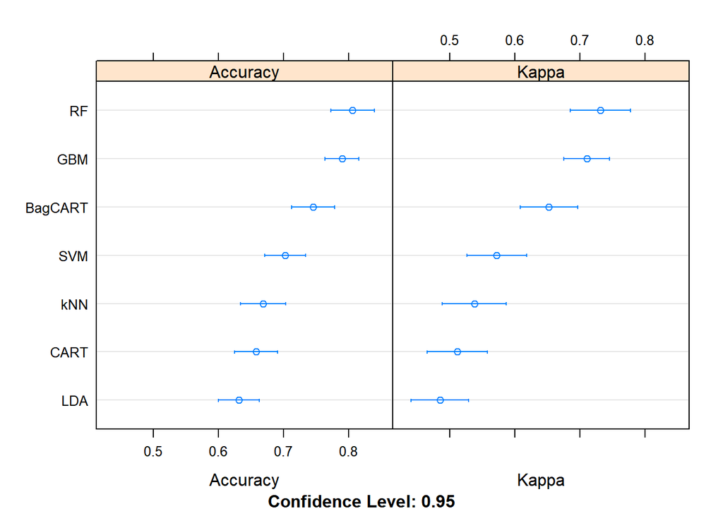

```r
dotplot(results)
```

```r
print(fit.rf)
```

```
## Random Forest
##
## 214 samples
##   9 predictor
##   6 classes: '1', '2', '3', '5', '6', '7'
##
## No pre-processing
## Resampling: Cross-Validated (10 fold, repeated 3 times)
## Summary of sample sizes: 194, 193, 192, 192, 192, 192, ...
## Resampling results across tuning parameters:
##
##   mtry  Accuracy   Kappa
##   2     0.8059747  0.7310980
##   5     0.7843224  0.7035534
##   9     0.7624980  0.6758341
##
## Accuracy was used to select the optimal model using the largest value.
## The final value used for the model was mtry = 2.
```

## 5. Improve Accuracy

After we achieve a short list of machine learning algorithms with good level of accuracy, we can leverage ways to improve the accuracy of the models:

- Search for a combination of parameters for each algorithm using caret that yields the best results.
- Combine the prediction of multiple models into an ensemble prediction using standalone algorithms or the caretEnsemble package.

### 5.a) Algorithm Tuning

```r
set.seed(seedNum)
grid <- expand.grid(.mtry=c(1:10))
rf_gridsearch <- train(Type~., data=dataset, method="rf", metric=metricTarget, tuneGrid=grid, trControl=control)
```

[output not shown]

[output cut: 34 more lines]

[output not shown]

```r
print(rf_gridsearch)
```

```
## Random Forest
##
## 214 samples
##   9 predictor
##   6 classes: '1', '2', '3', '5', '6', '7'
##
## No pre-processing
## Resampling: Cross-Validated (10 fold, repeated 3 times)
## Summary of sample sizes: 194, 193, 192, 192, 192, 192, ...
## Resampling results across tuning parameters:
##
##   mtry  Accuracy   Kappa
##    1    0.7967655  0.7158703
##    2    0.8011594  0.7239634
##    3    0.7967457  0.7192778
##    4    0.7948617  0.7175035
##    5    0.7858573  0.7053023
##    6    0.7780309  0.6958741
##    7    0.7561478  0.6658210
##    8    0.7573599  0.6687451
##    9    0.7561415  0.6660536
##   10    0.7593955  0.6716155
##
## Accuracy was used to select the optimal model using the largest value.
## The final value used for the model was mtry = 2.
```

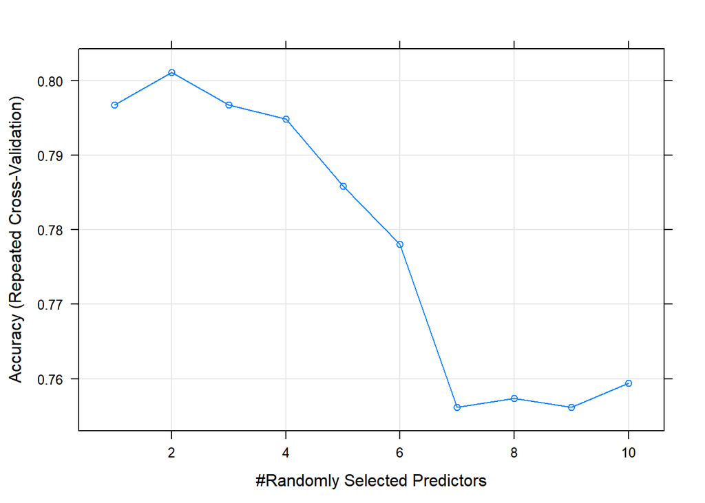

```r
plot(rf_gridsearch)
```

## 6. Finalize Model

Once we have narrow down to a model that we believe can make accurate predictions on unseen data, we are ready to finalize it. Finalizing a model may involve sub-tasks such as:

- Using an optimal model tuned to make predictions on unseen data.
- Creating a standalone model using the tuned parameters
- Saving an optimal model to file for later use.

### 6.a) Predictions on validation dataset

```r
# Not applicable for this iteration of the project.
```

### 6.b) Create standalone model on entire training dataset

```r
# Not applicable for this iteration of the project.
```

### 6.c) Save model for later use

```r
# Not applicable for this iteration of the project.
```